Krzysztof Ślot - UN - materiały do wykładu

# Autoenkodery

Koncepcja Autoenkodera (AE) to niezwykle pomysłowa metoda analizy i przekształcania danych, której pierwotnym zastosowaniem była rekonstrukcja zniekształconych danych (tzw. Autoenkodery odszumiające - Denoising Autoencoders), ale która okazała się posiadać znacznie ciekawsze możliwości. AE to uczący się algorytm parametryczny. Celem treningu jest znalezienie takich wartości parametrów, które zapewniają identycznościową transformację danych (wynik ma być taki sam jak dane wejściowe), a więc trening nie wymaga posiadania etykietowanych baz danych. Jeżeli algorytm przetwarzania danych będzie obejmował transformacje redukujące reprezentację danych (co wymaga później ekspansji do postaci oryginalnej), uzyskanie założonego celu, czyli rekonstrukcji danych wejściowych, przestaje być trywialne. Redukcja reprezentacji (zmniejszenie liczby elementów niosących informację wejściową) oznacza konieczność 'wymyślenia' opisu danych wejściowych, pozwalającego na jego rekonstrukcję. W efekcie, AE staje się narzędziem 'inteligentnej' kompresji danych, o stopniu określonym przez proporcje rozmiaru 'minimalnej' reprezentacji danych do reprezentacji oryginalnej (o ile każdy element reprezentacji ma taką samą pojemność bitową). Co więcej, treści zawarte w zredukowanej reprezentacji stanowią jakościowe komponenty danych wejściowych, których interpretacja może rzucić nowe światło na rozumienie informacji zawartej w danych. Wreszcie, możliwość identyfikacji powiązań między informacją zawartą w danych wejściowych a komponentami wytworzonej reprezentacji może stać się punktem wyjścia do celowych modyfikacji jakościowych atrybutów danych (np. 'postarzanie' lub 'odmładzanie' obrazu twarzy itp.).

Ogólna architektura AE to dwa funkcjonalne bloki: koder (Encoder), redukujący rozmiar reprezentacji danych wejściowych i dekoder (Decoder) - odtwarzający pierwotny rozmiar danych. Uzyskana na wyjściu kodera reprezentacja o minimalnym w AE rozmiarze jest nazywana reprezentacją ukrytą lub wektorem ukrytym (latent vector). Uczenie AE to procedura uczenia nienadzorowanego, w której na wejścia podawane są dane treningowe (np. obrazy), które mają zostać idealnie odtworzone. W efekcie, proces uczenia będzie kierunkowany przez funkcję oceniającą zgodność wyniku przetwarzania z oczekiwaniem, którą może być np. MSE lub binarna entropia skrośna (BCE - Binary Cross-Entropy).

## Architektury Autoenkoderów

Koncepcja AE nie stawia istotnych ograniczeń na architekturę algorytmu realizującego kodowanie i dekodowanie. Najprostszym wyborem jest realizacja kodera i dekodera jako zwykłych wielowarstwowych sieci jednokierunkowych (MLP). Stopień redukcji reprezentacji - liczba elementów wektora ukrytego dla rozważanego rozmiaru danych wejściowych, również nie może być z góry przewidziany, bo zależy on od stopnia złożoności treści zawartych w przetwarzanych danych.

```python
# Przykład: podstawowy AE uczony na zbiorze cyfr MNIST
```

```python
# Biblioteki do realizacji algorytmu
import numpy as np
import torch
import torch.nn as nn
import torchvision.transforms as T
import matplotlib.pyplot as plt


device = torch.device("cuda" if torch.cuda.is_available() else "cpu")
```

```python
# Przygotowanie danych do treningu AE
from torchvision.datasets import MNIST
from torch.utils.data import DataLoader

# F. pomocnicza: normalizacja danych wejściowych w zakresie min max
def min2max_normalization(X, low, high):
    X = (X - X.min())/(X.max() - X.min()) # zakres od 0 do 1
    X = X*(high-low) + low # zakres od low do high
    return X

# F. pomocnicza: sekwencja transformacji obrazów przed podaniem ich do sieci
img_transform = T.Compose([
    T.ToTensor(),
    T.Lambda(lambda tensor:min2max_normalization(tensor, 0, 1)),
])

batch_size = 50
# AE będzie uczony na danych ze zbioru MNIST
train_data = MNIST('./data', train = True, transform=img_transform, download=True)
# Redukcja liczby danych stosowanych do treningu (przyśpieszenie obliczeń, testy zjawiska overfitingu)
wsp_redukcji=10
reduced_set = torch.utils.data.Subset(train_data, range(0, len(train_data), wsp_redukcji))
# określenie liczebności zbiorów treningowego i walidacyjnego
n_train = int(0.8*len(reduced_set))
n_val = int(0.2*len(reduced_set))
# Podział na zbiory treningowy i walidacyjny
train_set, val_set = torch.utils.data.random_split(reduced_set, (n_train,n_val))
# Utworzenie 'samplerów' dla obydwu zbiorów
train_dataloader = DataLoader(train_set, batch_size=batch_size, shuffle=True)
val_dataloader = DataLoader(val_set, batch_size=batch_size, shuffle=True)
```

```python
# Autoenkoder: dwie sieci MLP dwuwarstwowe:
# Enkoder (redukuje obraz do wektora 10D) i Dekoder (ekspansja do rozmiaru oryginalnego)
# Obraz wejściowy będzie podawany na wejście w postaci 1D ('spłaszczony': kolejne wiersze)

class AE(nn.Module):

    def __init__(self):
        super().__init__()
        self.Enkoder = nn.Sequential(
            nn.Linear(28 * 28, 100),
            nn.ReLU(True),
            nn.Linear(100, 10),
            nn.ReLU(True))
        self.Dekoder = nn.Sequential(
            nn.Linear(10, 100),
            nn.ReLU(True),
            nn.Linear(100, 28 * 28),
            nn.Sigmoid())

    def forward(self, x):
        x = self.Enkoder(x)
        x = self.Dekoder(x)
        return x
```

```python
# Trening sieci i rejestracja postepów na zbiorach treningowym i walidacyjnym

# utworzenie sieci i skierowanie jej do wykonania na wybraną platformę (CPU lub GPU)
ae = AE().to(device)

criterion = nn.BCELoss() # alternatywą może być nn.MSELoss
optimizer = torch.optim.Adam( ae.parameters() ) # wszystkie parametry AE podlegają optymalizacji
# zmienne 'logujące' wartości kryterium (osobno dla zbiorów tr i val) dla poszczególnych epok treningu
train_loss = []
val_loss = []
# trening
n_epochs = 100
for epoch in range(n_epochs):
    mean_loss = 0 # dla epoki obliczony będzie średni loss dla wszystkich batch'y
    ae.train() # uaktywnienie procesu wyznaczania gradientów na potrzeby treningu
    for data in train_dataloader:  # batch sampling
        img, _ = data # nie interesują nas etykiety ('pusta' zmienna)
        img = img.view(img.size(0), -1) # wypłaszczenie obrazu przed podaniem go na sieć
        # ===================forward pass =====================
        output = ae(img.to(device))
        loss = criterion(output, img.to(device)) # obliczenie wartości kryterium
        mean_loss += loss.item()
        # ===================backward pass====================
        optimizer.zero_grad()
        loss.backward()
        optimizer.step()
    # =================== rejestracja średniego training loss dla epoki ========================
    mean_loss /= len(train_dataloader)
    train_loss.append(mean_loss)
    mean_loss = 0
    # =============== ocena na zbiorze walidacyjnym =====================
    ae.eval() # wyłączenie rejestracji gradientów (tylko sprawdzanie działania sieci)
    for val_data in val_dataloader:
        X, _ = val_data
        X = X.view(X.shape[0],-1) # wypłaszczenie danych przed podaniem do sieci
        out = ae(X.to(device))
        loss = criterion(out,X.to(device))
        mean_loss += loss.item()
    # =============== rejestracja średniego validation loss =================
    mean_loss /= len(val_dataloader)
    val_loss.append(mean_loss)
    # ============= informacje o przebiegu uczenia
    if (epoch+1)%(n_epochs//10)==0:
        print('epoch [{}/{}], train_loss:{:.4f},  val_loss:{:.4f}'
              .format(epoch + 1, n_epochs, train_loss[-1], val_loss[-1]))
```

```
epoch [10/100], train_loss:0.1615,  val_loss:0.1614
epoch [20/100], train_loss:0.1461,  val_loss:0.1477
epoch [30/100], train_loss:0.1382,  val_loss:0.1413
epoch [40/100], train_loss:0.1344,  val_loss:0.1383
epoch [50/100], train_loss:0.1316,  val_loss:0.1368
epoch [60/100], train_loss:0.1296,  val_loss:0.1357
epoch [70/100], train_loss:0.1280,  val_loss:0.1350
epoch [80/100], train_loss:0.1268,  val_loss:0.1346
epoch [90/100], train_loss:0.1258,  val_loss:0.1341
epoch [100/100], train_loss:0.1250,  val_loss:0.1341
```

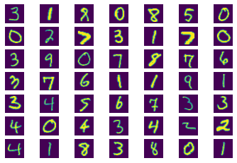

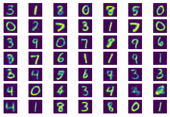

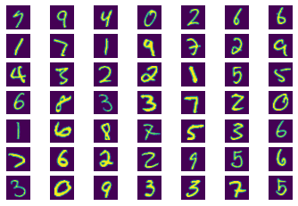

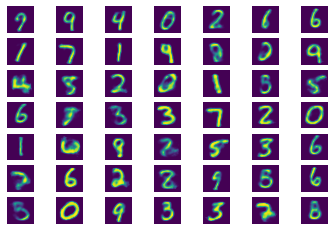

```python
# Wizualizacja wyników uczenia

# utworzenie obrazów in/out z ostatniego batch'a dla zbiorów treningowego i walidacyjnego
in_img_train = img.view(img.shape[0],1,28,28).cpu().data.numpy()
out_img_train = output.view(output.shape[0],1,28,28).cpu().data.numpy()
in_img_val = X.view(X.shape[0],1,28,28).cpu().data.numpy()
out_img_val = out.view(out.shape[0],1,28,28).cpu().data.numpy()

# określenie rozmiaru mozaiki z obrazami na podstawie rozmiaru batcha
n = np.floor(np.sqrt(batch_size)).astype(int)
# umieszczenie zbiorów obrazów na liście (by zautomatyzować wizualizację)
imgs = [in_img_train, out_img_train, in_img_val, out_img_val]

# wyświetlenie obrazów: we i wy dla zbioru treningowego (nr 1 i 2) oraz we/wy dla zb. walidacyjnego (nr 3 i 4)
for k in range(len(imgs)):
    fig, axs = plt.subplots(n,n)
    for i in range(n):
        for j in range(n):
            axs[i,j].imshow(imgs[k][i*n+j,0,:,:])
            axs[i,j].axis('off')
```

```python
from torchinfo import summary

print(summary(ae,(1,28*28)))
```

```
==========================================================================================
Layer (type:depth-idx)                   Output Shape              Param #
==========================================================================================
AE                                       --                        --
├─Sequential: 1-1                        [1, 10]                   --
│    └─Linear: 2-1                       [1, 100]                  78,500
│    └─ReLU: 2-2                         [1, 100]                  --
│    └─Linear: 2-3                       [1, 10]                   1,010
│    └─ReLU: 2-4                         [1, 10]                   --
├─Sequential: 1-2                        [1, 784]                  --
│    └─Linear: 2-5                       [1, 100]                  1,100
│    └─ReLU: 2-6                         [1, 100]                  --
│    └─Linear: 2-7                       [1, 784]                  79,184
│    └─Sigmoid: 2-8                      [1, 784]                  --
==========================================================================================
Total params: 159,794
Trainable params: 159,794
Non-trainable params: 0
Total mult-adds (M): 0.16
==========================================================================================
Input size (MB): 0.00
Forward/backward pass size (MB): 0.01
Params size (MB): 0.64
Estimated Total Size (MB): 0.65
==========================================================================================
```

Przedstawione wyniki pokazują poprawność uczenia się AE cyfr. Ponieważ ograniczono liczbę przykładów (w przykładzie - 10-krotnie) oraz trening trwał 100 epok, prawdopodobnie wyniki uczenia mogą być znacznie lepsze. Struktura AE jest dość duża - proszę zauważyć, że nie stosowałem żadnych mechanizmów regularyzacyjnych, ale mimo to dla użytej liczby przykładów nie zaobserwowano tendencji 'przeuczania' sieci (strata na zbiorze walidacyjnym maleje). Zachęcam do samodzielnych testów ...

### Autoenkodery odszumiające

AE odszumiające (Denoising AEs) to nazwa identyfikująca aplikację architektury przedstawionej w poprzedniej części, a nie nowa architektura. Dlatego też, jedyna modyfikacja w implementacji AE dotyczy fragmentów związanych z dodatkowym zaszumianiem obrazów podawanych na wejścia AE

```python
# Procedura dodawania szumu o rozkładzie równomiernym z zakresu [0...1]
def addNoise(X):
    Y = X + 1*(torch.rand(X.shape)-0.5)
    Y = torch.clamp(Y,min=0,max=1)
    return Y
```

```python
ae = AE().to(device)

criterion = nn.BCELoss()
optimizer = torch.optim.Adam( ae.parameters() )

train_loss = []
val_loss = []
n_epochs = 300
for epoch in range(n_epochs):
    mean_loss = 0
    ae.train()
    for data in train_dataloader:
        img, _ = data
        img = img.view(img.size(0),-1)
        noisy_img = addNoise(img) # zaszumienie obrazu
        # ===================forward=====================
        output = ae(noisy_img.to(device)) # przetwarzany obraz zaszumiony
        loss = criterion(output, img.to(device)) # wynik porównywany z obrazem oryginalnym
        mean_loss += loss.item()
        # ===================backward====================
        optimizer.zero_grad()
        loss.backward()
        optimizer.step()
    # ===================log========================
    mean_loss /= len(train_dataloader)
    train_loss.append(mean_loss)
    mean_loss = 0
    # =============== validate =====================
    ae.eval()
    for val_data in val_dataloader:
        X, _ = val_data
        X = X.view(X.size(0),-1)
        noisy_X = addNoise(X)
        out = ae(noisy_X.to(device))
        loss = criterion(out,X.to(device))
        mean_loss += loss.item()
    mean_loss /= len(val_dataloader)
    val_loss.append(mean_loss)
    if (epoch+1)%(n_epochs//10)==0:
        print('epoch [{}/{}], train_loss:{:.4f},  val_loss:{:.4f}'
              .format(epoch + 1, n_epochs, train_loss[-1], val_loss[-1]))

# ===========  generacja obrazów in/out na podstawie ostatniego batch'a

in_img_train = noisy_img.view(img.shape[0],1,28,28).cpu().data.numpy()
out_img_train = output.view(output.shape[0],1,28,28).cpu().data.numpy()

in_img_val = noisy_X.view(X.shape[0],1,28,28).cpu().data.numpy()
out_img_val = out.view(out.shape[0],1,28,28).cpu().data.numpy()
```

```
epoch [30/300], train_loss:0.1573,  val_loss:0.1611
epoch [60/300], train_loss:0.1490,  val_loss:0.1544
epoch [90/300], train_loss:0.1450,  val_loss:0.1513
epoch [120/300], train_loss:0.1428,  val_loss:0.1502
epoch [150/300], train_loss:0.1416,  val_loss:0.1497
epoch [180/300], train_loss:0.1406,  val_loss:0.1492
epoch [210/300], train_loss:0.1398,  val_loss:0.1486
epoch [240/300], train_loss:0.1395,  val_loss:0.1487
epoch [270/300], train_loss:0.1389,  val_loss:0.1480
epoch [300/300], train_loss:0.1385,  val_loss:0.1484
```

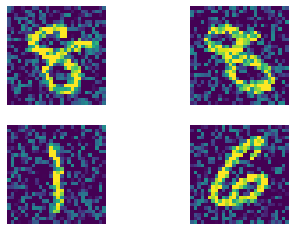

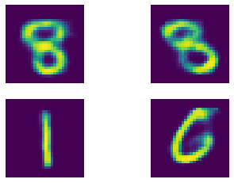

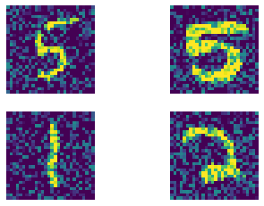

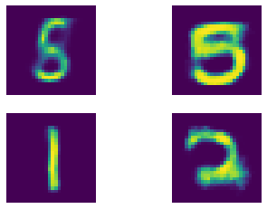

```python
# tym razem wyświetlane są tylko cztery obrazy / batch
imgs = [in_img_train, out_img_train, in_img_val, out_img_val]

for k in range(len(imgs)):

    fig, axs = plt.subplots(2,2)
    for i in range(2):
        for j in range(2):
            axs[i,j].imshow(imgs[k][i*2+j,0,:,:])
            axs[i,j].axis('off')
```

### Autoenkodery konwolucyjne (CAE)

Autoenkodery konwolucyjne są przeznaczone do analizy danych (przede wszystkim - obrazów), w których spodziewamy się, że istotne relacje między komponentami budującymi dane wejściowe mają charakter lokalny i niezależny od lokalizacji znaczących treści w obrębie tych danych. Redukcja rozmiaru danych dokonywana w koderze nie zawiera żadnych koncepcyjnych nowości - podobnie jak w w ekstraktorze klasyfikatora konwolucyjnego, enkoder zawiera sekwencję modułów konwolucyjnych, decymujących i nieliniowych, która może być zakończona 'wypłaszczeniem' do wektora 1D (ale wcale nie musi - reprezentacja ukryta może być tensorem2D lub 3D).

Inaczej jest w odniesieniu do dekodera, w którym dla odtworzenia obrazu wyjściowego, zamiast sieci MLP, można zastosować manipulacje na tensorach, stanowiące odwrócenie zastosowanej metodyki redukcji rozmiaru. Jeżeli wektor ukryty jest jednowymiarowy, a argumentem przetwarzania w Autoenkoderze jest obraz, pierwszą operacją dekodera może być 'uformowanie' wektora ukrytego 1D w strukturę 3D, taką, jaką miał przed 'wypłaszczeniem'. Celem kolejnych operacji, dokonywanych na tensorach, będzie zwiększanie ich 'szerokości' i 'wysokości' tak, by w ostatnim kroku doprowadzić do struktury odpowiadającej danym wejściowym. Podstawowym sposobem realizacji ekspansji rozmiaru tensora, powiększającego jego 'szerokość' i 'wysokość' jest tzw. transponowana konwolucja.

Transponowana konwolucja, nazywana też konwolucją z 'ułamkowym' krokiem, jest operacją, w której dane wyjściowe będą miały rozmiary większe niż dane wejściowe, co osiąga się poprzez przeplatanie elementów obrazu wejściowego wierszami/kolumnami (np. zawierającymi zera), zwiększając w efekcie rozmiar danych wejściowych. Wagi filtrów są podczas treningu modyfikowane w sposób zapewniający pożądane przeskalowanie treści o mniejszym rozmiarze w treści o większym rozmiarze.

```python
# Autoenkoder konwolucyjny

class CAE(nn.Module):

    def __init__(self):
        super().__init__()
        self.Encoder = nn.Sequential(
            # Enkoder ma strukturę typową dla zwykłych klasyfikatorów głębokich
            nn.Conv2d(1, out_channels=16, kernel_size=3, padding=1),
            nn.ReLU(inplace=True),
            nn.MaxPool2d(kernel_size=2), # rozmiar: 14x14
            nn.Conv2d(16, out_channels=32, kernel_size=3), # po splocie rozmiar 12x12
            nn.ReLU(True),
            nn.MaxPool2d(kernel_size=2), # rozmiar 6x6 x 32
            nn.Flatten(),
            nn.Linear(in_features=6*6*32, out_features=16),
            nn.ReLU(True)
            )
        self.Decoder = nn.Sequential(
            nn.Linear(in_features=16, out_features=6*6*32),
            nn.ReLU(True),
            # Powrót do tensora - konwersja wektora 1D w tensor
            nn.Unflatten(dim=1, unflattened_size=(32,6,6)),
            # Pierwsza warstwa powiększania rozmiaru obrazu
            nn.ConvTranspose2d(in_channels=32, out_channels=16, kernel_size=3,
                               stride=2),# rozmiar po operacji to 13x13
            nn.ReLU(True),
            nn.ConvTranspose2d(in_channels=16, out_channels=1, kernel_size=3,
                               stride=2, output_padding=1), # rozmiar 28x28
            nn.Sigmoid()
            )

    def forward(self,x):
        x = self.Encoder(x)
        x = self.Decoder(x)
        return x
```

```python
ae = CAE().to(device)

n_epochs = 100
criterion = nn.BCELoss()
optimizer = torch.optim.Adam( ae.parameters() )

train_loss = []
val_loss = []

for epoch in range(n_epochs):
    mean_loss = 0
    ae.train()
    for data in train_dataloader:
        # poprzednio, konieczne było 'wypłaszczenie' obrazu, teraz CAE ma wejście 2D
        img, _ = data
        # ===================forward=====================
        output = ae(img.to(device))
        loss = criterion(output, img.to(device))
        mean_loss += loss.item()
        # ===================backward====================
        optimizer.zero_grad()
        loss.backward()
        optimizer.step()
    # ===================log========================
    mean_loss /= len(train_dataloader)
    train_loss.append(mean_loss)
    mean_loss = 0
    # =============== validate =====================
    ae.eval()
    for val_data in val_dataloader:
        X, _ = val_data
        out = ae(X.to(device))
        loss = criterion(out,X.to(device))
        mean_loss += loss.item()
    mean_loss /= len(val_dataloader)
    val_loss.append(mean_loss)
    if (epoch+1)%(n_epochs//10)==0:
        print('epoch [{}/{}], train_loss:{:.4f},  val_loss:{:.4f}'
              .format(epoch + 1, n_epochs, train_loss[-1], val_loss[-1]))
```

```
epoch [10/100], train_loss:0.1913,  val_loss:0.1917
epoch [20/100], train_loss:0.1634,  val_loss:0.1658
epoch [30/100], train_loss:0.1478,  val_loss:0.1508
epoch [40/100], train_loss:0.1382,  val_loss:0.1426
epoch [50/100], train_loss:0.1322,  val_loss:0.1372
epoch [60/100], train_loss:0.1282,  val_loss:0.1338
epoch [70/100], train_loss:0.1255,  val_loss:0.1316
epoch [80/100], train_loss:0.1237,  val_loss:0.1297
epoch [90/100], train_loss:0.1222,  val_loss:0.1287
epoch [100/100], train_loss:0.1211,  val_loss:0.1282
```

```python
# ===========  generacja obrazów in/out na podstawie ostatniego batch'a

in_img_train = img.view(img.shape[0],1,28,28).cpu().data.numpy()
out_img_train = output.view(output.shape[0],1,28,28).cpu().data.numpy()

in_img_val = X.view(X.shape[0],1,28,28).cpu().data.numpy()
out_img_val = out.view(out.shape[0],1,28,28).cpu().data.numpy()
```

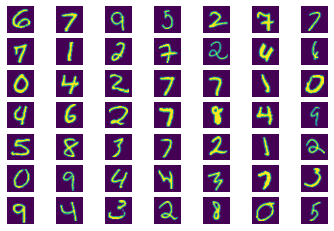

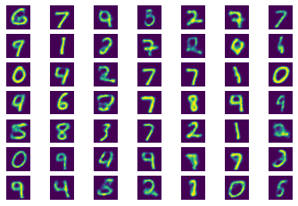

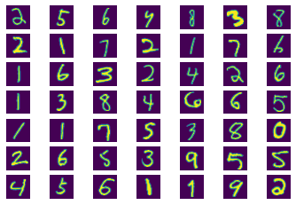

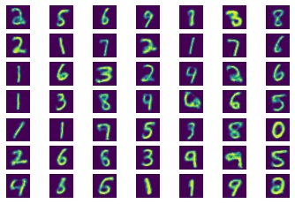

```python
#-------------------  Wizualizacja wyników --------------------------------


n = np.floor(np.sqrt(batch_size)).astype(int)
imgs = [in_img_train, out_img_train, in_img_val, out_img_val]

for k in range(len(imgs)):

    fig, axs = plt.subplots(n,n)
    for i in range(n):
        for j in range(n):
            axs[i,j].imshow(imgs[k][i*n+j,0,:,:])
            axs[i,j].axis('off')
```

O ile wyniki przetwarzania w CAE nie odbiegają od wyników uzyskanych we wcześniej przedstawionej architekturze, o tyle liczba parametrów dla CAE jest kilkukrotnie mniejsza

```python
from torchinfo import summary
print(summary(ae,(batch_size,1,28,28)))
```

```
==========================================================================================
Layer (type:depth-idx)                   Output Shape              Param #
==========================================================================================
CAE                                      --                        --
├─Sequential: 1-1                        [50, 16]                  --
│    └─Conv2d: 2-1                       [50, 16, 28, 28]          160
│    └─ReLU: 2-2                         [50, 16, 28, 28]          --
│    └─MaxPool2d: 2-3                    [50, 16, 14, 14]          --
│    └─Conv2d: 2-4                       [50, 32, 12, 12]          4,640
│    └─ReLU: 2-5                         [50, 32, 12, 12]          --
│    └─MaxPool2d: 2-6                    [50, 32, 6, 6]            --
│    └─Flatten: 2-7                      [50, 1152]                --
│    └─Linear: 2-8                       [50, 16]                  18,448
│    └─ReLU: 2-9                         [50, 16]                  --
├─Sequential: 1-2                        [50, 1, 28, 28]           --
│    └─Linear: 2-10                      [50, 1152]                19,584
│    └─ReLU: 2-11                        [50, 1152]                --
│    └─Unflatten: 2-12                   [50, 32, 6, 6]            --
│    └─ConvTranspose2d: 2-13             [50, 16, 13, 13]          4,624
│    └─ReLU: 2-14                        [50, 16, 13, 13]          --
│    └─ConvTranspose2d: 2-15             [50, 1, 28, 28]           145
│    └─Sigmoid: 2-16                     [50, 1, 28, 28]           --
==========================================================================================
Total params: 47,601
Trainable params: 47,601
Non-trainable params: 0
Total mult-adds (M): 86.34
==========================================================================================
Input size (MB): 0.16
Forward/backward pass size (MB): 8.72
Params size (MB): 0.19
Estimated Total Size (MB): 9.07
==========================================================================================
```

### Autoenkodery rzadkie (Sparse Autoencoders)

Jedną z najciekawszych właściwości jakie daje koncepcja AE jest możliwość ekstrakcji z danych wejściowych istotnej informacji dla zawartych w nich treści. Informacja ta, reprezentowana w postaci wektora ukrytego może być, jako wcześniej pokazano, wykorzystana pośrednio do usuwania szumu lub jako skompresowana reprezentacja danych. Innym pomysłem na wykorzystanie reprezentacji ukrytej jest próba jej wykorzystania do generacji nowych treści, ale aby było to możliwe, reprezentacja ukryta powinna mieć intepretowalne znaczenie (zawierać cechy danych wejściowych możliwe do identyfikacji). Ponieważ reprezentacja ukryta jest silnie zredukowana, każda z cech odpowiada za kombinację rozmaitych właściwości danych wejściowych, które być może odpowiadają semantycznym komponentom treści obrazu. Aby sprawdzić, jakie treści uznawane są kluczowe z punktu widzenia rekonstrukcji danych wejściowych zaproponowano, by procedurę uczenia autoenkodera uzupełnić o próbę wymuszenia odpowiedniej formy wektora ukrytego. Na przykład, żądania, by w reprezentacji ukrytej istotna dla rekonstrukcji obiektu była tylko wartość na jednej (lub niewielkiej liczbie), wybranej pozycji, a pozostałe były zerowe. Wtedy obserwacja wyniku rekonstrukcji wektora ukrytego, zawierającego '1' na wybranych pozycjach dałaby informację o tym jakie komponenty obrazów wejściowych zostały w procesie uczenia wybrane jako najlepsza podstawa opisu danych wejściowych. Dodatkowo, identyfikacja takich 'semantycznych' cech pozwoliłaby na uzyskanie innego, niezwyklego istotnego celu: wprowadzania ukierunkowanych modyfikacji do treści obrazów poprzez manipulację wartościami elementów wektora ukrytego.

Osiągnięcie założonych celów wymaga zdefiniowania złożonej funkcji kryterialnej, zawierającej oprócz typowego komponentu oceny jakości rekonstrukcji (przeprowadzanej z użyciem miar takich jak MSE lub BCE), również drugiego komponentu, oceniającego stopień 'rzadkości' (sparsity) zawartości wektora ukrytego. W efekcie, funkcja kosztu przyjmuje wtedy postać:

\begin{equation} L = L_{MSE/BCE} + \lambda L_{sparsity} \end{equation}

gdzie ocena 'rzadkości' wektora może być dokonywana na różne sposoby, z których najprostszym jest użycie regularyzacji L1. Omawiana wcześniej regularyzacja L1 była kandydatem na redukcję ryzyka 'overfittingu' przy treningu sieci, a argumentem regularyzacji był wektor wag sieci. Tym razem, argumentem regularyzacji stają się wartości wektora ukrytego, a możliwą postacią kryterium treningu jest:

\begin{equation} L^k = \sum_i \sum_j (x^k_{ij} - y^k_{ij})^2 + \lambda \sum_l | z^k_l| \end{equation}

gdzie $z_k_l$ to $l$-ty element wektora ukrytego, a $x_{ij},y_{ij}$ to elementy obrazów wejściowego i zrekonstruowanego.

Alternatywnym pomysłem na wymuszenie oczekiwanej postaci wektora ukrytego (one-hot) jest użycie jako kryterium dywergencji Kullbacka-Leiblera, w której jednym argumentem jest rozkład wartości elementów wektora ukrytego uzyskiwanych dla batch'a, a drugim - rozkład dwumianowy.

Autoenkodery z wymuszaniem 'rzadkiej' reprezentacji ukrytej nazywane są Autoenkoderami rzadkimi (Sparse AE).

```python
# Definicja Autoenkodera rzadkiego z kryterium L1 wymuszania rzadkości wektora ukrytego

class SAE(nn.Module):

    def __init__(self):
        super().__init__()
        self.Enkoder = nn.Sequential(
            nn.Linear(28 * 28, 100),
            nn.ReLU(True),
            nn.Linear(100, 20),
            nn.ReLU(True))
        self.Dekoder = nn.Sequential(
            nn.Linear(20, 100),
            nn.ReLU(True),
            nn.Linear(100, 28 * 28),
            nn.Sigmoid())

    def forward(self, x):
        # Modyfikacja w stosunku do wcześniejszego kodu: elementem kosztu będzie wymaganie
        # 'rzadkości' wartości wektora ukrytego, co można uzyskać np. za pomocą regularyzacji L1
        # W tym celu dołączam wektor ukryty do 'grafu' (dzięki temu w obliczeniach uwzględniane są
        # pochodne funkcji określonej na wartościach wektora względem parametrów)
        # Alternatywa L1 to dywergencja KL względem rozkładu dwumianowego
        h = Variable(self.Enkoder(x), requires_grad=False)
        z = h.cpu().data.numpy()
        # Zmienna L1 to średni wektor modułów elementów wektora ukrytego
        self.L1 = np.sum(np.abs(z))/z.shape[0]
        x = self.Dekoder(h)
        return x
        # Funkcja dostępu do wyliczonej wartości czynnika regularyzującego
    def getL1(self):
        return self.L1
        # Funkcja pozwalająca na generację treści w wytrenowanym AE
    def dekoduj(self,x):
        with torch.no_grad():
            y = self.Dekoder(x)
        return y
        # Funkcja zamieniająca obraz we w wektor ukryty - do inspekcji zawartości
    def koduj(self,x):
        with torch.no_grad():
            z = self.Enkoder(x)
        return z
```

```python
from torch.autograd import Variable

ae = SAE().to(device)

n_epochs = 100
criterion = nn.BCELoss()
optimizer = torch.optim.Adam( ae.parameters() )

train_loss = []
val_loss = []
ksi = 0.25
# Ponieważ kryterium L1 dotyczy pojedynczego wektora ukrytego, niestety konieczna jest redukcja
batch_size = 1
train_dataloader = DataLoader(train_set, batch_size=batch_size, shuffle=True)
val_dataloader = DataLoader(val_set, batch_size=batch_size, shuffle=True)


for epoch in range(n_epochs):
    mean_loss = 0
    ae.train()
    for data in train_dataloader:
        img, _ = data
        img = img.view(img.size(0),-1)
        # ===================forward=====================
        output = ae(img.to(device))
        loss = criterion(output, img.to(device)) + ksi*ae.getL1()
        mean_loss += loss.item()
        # ===================backward====================
        optimizer.zero_grad()
        loss.backward()
        optimizer.step()
    # ===================log========================
    mean_loss /= len(train_dataloader)
    train_loss.append(mean_loss)
    mean_loss = 0
    # =============== validate =====================
    ae.eval()
    with torch.no_grad():
        for val_data in val_dataloader:
            X, _ = val_data
            X = X.view(X.size(0),-1)
            out = ae(X.to(device))
            loss = criterion(out,X.to(device))
            mean_loss += loss.item()
    mean_loss /= len(val_dataloader)
    val_loss.append(mean_loss)
    if (epoch+1)%(n_epochs//10)==0:
        print('epoch [{}/{}], train_loss:{:.4f},  val_loss:{:.4f}'
              .format(epoch + 1, n_epochs, train_loss[-1], val_loss[-1]))
```

```
epoch [10/100], train_loss:0.4833,  val_loss:0.2001
epoch [20/100], train_loss:0.4761,  val_loss:0.1945
epoch [30/100], train_loss:0.4727,  val_loss:0.1921
epoch [40/100], train_loss:0.4705,  val_loss:0.1913
epoch [50/100], train_loss:0.4689,  val_loss:0.1906
epoch [60/100], train_loss:0.4677,  val_loss:0.1901
epoch [70/100], train_loss:0.4668,  val_loss:0.1902
epoch [80/100], train_loss:0.4662,  val_loss:0.1900
epoch [90/100], train_loss:0.4656,  val_loss:0.1904
epoch [100/100], train_loss:0.4652,  val_loss:0.1898
```

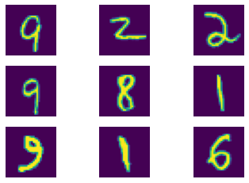

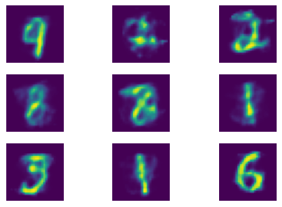

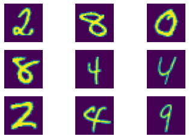

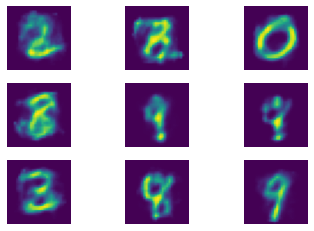

```python
# Ponieważ batch_size=1 generacja n=9 obrazów ze zbiorów treningowego i testowego

n=3
ae.eval()
batch_size = n**2
train_loader = DataLoader(train_set, batch_size=batch_size, shuffle=True)
val_loader = DataLoader(val_set, batch_size=batch_size, shuffle=True)


with torch.no_grad():
    img, _ = next(iter(train_loader))
    img = img.view(img.size(0),-1)
    output = ae(img.to(device))

in_img_train = img.view(img.shape[0],1,28,28).cpu().data.numpy()
out_img_train = output.view(output.shape[0],1,28,28).cpu().data.numpy()

with torch.no_grad():
    X, _ = next(iter(val_loader))
    X = X.view(X.size(0),-1)
    out = ae(X.to(device))

in_img_val = X.view(X.shape[0],1,28,28).cpu().data.numpy()
out_img_val = out.view(out.shape[0],1,28,28).cpu().data.numpy()

imgs = [in_img_train, out_img_train, in_img_val, out_img_val]

for k in range(len(imgs)):
    fig, axs = plt.subplots(n,n)
    for i in range(n):
        for j in range(n):
            axs[i,j].imshow(imgs[k][i*n+j,0,:,:])
            axs[i,j].axis('off')
```

Wyniki uczenia nie są oszałamiające, ale znowu należy pamiętać, że uczenie odbywało się na ograniczonym zbiorze danych (10% zbioru MNIST) i przez ograniczoną liczbę epok. Istotnym efektem uczenia jest wgląd w wartości wektora ukrytego i sprawdzenie, czy dla różnych cyfr rzeczywiście ma on strukturę 'rzadką'.

```python
#--------------- Analiza przestrzeni ukrytej

# podanie na wejście wytrenowanej sieci danych z ostatniego batch'a
Aktywacje = ae.koduj(img.cuda())
Aktywacje = Aktywacje.cpu().data.numpy()
# Macierz aktywacje to zbiór wektorów ukrytych dla AE trenowanego z L1
print(Aktywacje)
```

```
[[0.12468763 0.         0.03574259 0.         0.         0.
  0.00633816 0.06892093 0.15962556 0.08355139 0.         0.08234324
  0.16946433 0.04683107 0.         0.07981803 0.021044   0.
  0.1029906  0.        ]
 [0.04983272 0.13115855 0.00753964 0.         0.0940305  0.05683431
  0.10530323 0.00914829 0.07962634 0.         0.         0.
  0.11873381 0.05824974 0.         0.         0.         0.
  0.09213781 0.        ]
 [0.1446256  0.         0.         0.         0.01971255 0.06771103
  0.11916348 0.00065488 0.13221256 0.09092197 0.         0.06530501
  0.15633547 0.00545803 0.         0.18064973 0.         0.
  0.14443476 0.        ]
 [0.03313838 0.05190704 0.         0.         0.10039855 0.
  0.1053409  0.01600007 0.16474776 0.04697426 0.         0.0632542
  0.12141255 0.11809415 0.         0.03460634 0.00472742 0.
  0.10458278 0.        ]
 [0.06792574 0.07090537 0.00646219 0.         0.1454166  0.07410255
  0.04037926 0.         0.18351531 0.04329765 0.         0.02940797
  0.16334288 0.13181417 0.         0.         0.         0.
  0.17984833 0.        ]
 [0.09594259 0.05859054 0.01369783 0.         0.06153125 0.
  0.04055    0.057015   0.11109613 0.07278602 0.         0.05699687
  0.10409109 0.07762995 0.         0.09173208 0.         0.
  0.08753169 0.        ]
 [0.07284579 0.07124107 0.02594021 0.         0.01439836 0.
  0.         0.05315506 0.16582152 0.03912042 0.07761828 0.16335063
  0.17169335 0.04729706 0.         0.04527076 0.         0.
  0.22847058 0.        ]
 [0.02381223 0.07943879 0.06529597 0.         0.05395878 0.
  0.03654359 0.09060233 0.097762   0.0501527  0.00085616 0.12436458
  0.1669317  0.11301491 0.         0.09935755 0.         0.
  0.09354551 0.        ]
 [0.06358723 0.04986725 0.00663736 0.         0.06918994 0.
  0.07004929 0.         0.23785642 0.07596047 0.         0.04715401
  0.16850036 0.09788494 0.         0.11877106 0.09202169 0.06971061
  0.21316113 0.        ]]
```

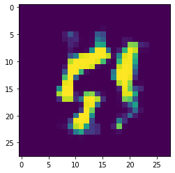

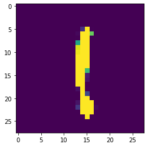

```python
# reprezentacja ukryta w rozważanym modelu na wymiar 20, batch ma 2 elementy
v = np.zeros((2,20))
# wstawiam '1' na pierwszą pozycję wektora ukrytego nr 1
v[0,1] = 1
# i '1' na 7 pozycję wektora nr 2
v[1,7] = 1
z = torch.cuda.FloatTensor(v)#, dtype='float')
y = ae.dekoduj(z)#.cuda())

plt.figure()
im = y.cpu().data.numpy()
plt.imshow(np.squeeze(im[0,:]).reshape((28,28)))
plt.figure()
plt.imshow(np.squeeze(im[1,:]).reshape((28,28)))
```

## Autoenkodery wariacyjne (Variational Autoencoders - VAE)

Podstawowa koncepcja AE pozwala na realizację istotnych zadań przetwarzania obrazów lub danych jednowymiarowych, takich jak kompresja, usuwanie zakłóceń (lub usuwanie powtarzalnych struktur, takich jak np. znaki wodne), tworzenie reprezentacji danych wielkowymiarowych bez konieczności posiadania etykietowanego zbioru, czy uzupełnianie niekompletnych obrazów treścią o charakterze zbliżonym do pozostałej zawartości obrazu (ang. inpainting). Jednakże próby uzyskania dobrych efektów ekstrakcji z obrazów reprezentacji 'semantycznej', zawierającej kluczowe i zrozumiałe dla wyglądu obrazu atrybuty wysokiego poziomu (np. w odniesieniu do obrazów twarzy mogą to być położenie, orientacja, makijaż, okulary itp.), nie dały zadowalających rezultatów (również dla AE rzadkich). Możliwość takiego ukierunkowania procesu uczenia AE, by elementy wektora ukrytego reprezentowały konkretne treści obrazu, wcale nie jest oczywista. Uprawnionym efektem uczenia może być nauczenie się w przestrzeni ukrytej indeksów przetwarzanych klas (np. jeśli w zbiorze treningowym mamy obiekty 10 klas, może się okazać, że w przestrzeni ukrytej zostanie zakodowana informacjs o przynależności obrazu do klasy, która będzie służyć dekoderowi do generacji odpowiedniej treści wynikowej. Dodatkowo, nawet jeśli reprezentacja ukryta odzwierciedla treści zawarte w danych wejściowych, w AE nie istnieje żaden mechanizm pozwalający na zachowanie spójności reprezentacji ukrytej z rozkładem próbek wejściowych (tzn. bliskie sobie treści danych wejściowych wcale nie muszą przekładać się na podobne do siebie wektory ukryte).

Autoenkodery wariacyjne są koncepcją opracowaną specjalnie pod kątem zapewnienia możliwości budowania semantycznej przestrzeni cech. Punktem wyjścia dla VAE jest założenie, że treść danych wejściowych jest w istocie generowana w pewnej ukrytej przestrzeni semantycznej, a następnie, jest przekształcanaz za pomocą nieznanej transformacji do obserwowalnej postaci, czyli obrazów lub sygnałów. Ponieważ złożoność tej transformacji nie jest niczym ograniczona, proces generujący treści można modelować za pomocą arbitralnego rozkładu prawdopodobieństwa. Prostym kandydatem jest tu rozkład normalny, a więc rozkład o zerowej wartości średniej i jednostkowej macierzy kowariancji, o mimnimalnej wymiarowości zapewniającej możliwość generacji dowolnego obiektu rozważanych kategorii. Formalnie, można to określić jako:

\begin{equation} \mathbf{z} \in \mathcal{N}(\boldsymbol{\mu}=0, \boldsymbol{C}=\mathbf{1}) \rightarrow \mathbf{x} \end{equation}

Wygenerowane dane - $\mathbf{x}$ można traktować jako zmienną losową, wygenerowanę z prawdopodobieństwem $p_\theta (\mathbf{x}/\mathbf{z}$, gdzie $\theta$ to parametry nieznanej funkcji przekształcającej 'pierwotną' treść w próbkę. Pomysłem jaki stoi za koncepcją VAE jest założenie, że równorzędnym celem uczenia autoenkodera, oprócz uzyskania rekonstrukcji danych wejściowych, będzie próba nauczenia się przez algorytm reprezentacji przybliżającej nieznany rozkład normalny. Oznacza to, że wektor ukryty będzie stanowił probabilistyczny opis rozkładu, z którego losowane będą próbki do dekodowania. Ponieważ założono, że rzeczywisty rozkład treści jest normalny, naturalnym kandydatem na reprezentację ukrytą jest rozkład Gaussa: każdy element reprezentacji ukrytej będzie zawierać dwa parametry - wartość średnią i odchylenie standardowe dla tego komponentu. Celem uczenia będzie więc próba doprowadzenia, by obydwa parametry kolejnych elementów wektora ukrytego dążyły do wartości 'zero' dla wartości średniej i 'jeden' dla odchylenia standardowego.

Mechanizmem wymuszającym naukę oczekiwanego rozkładu prawdopodobieństwa jest włączenie do funkcji kryterialnej sterującej przebiegiem treningu komponentu oceniającego podobieństwo bieżącego i oczekiwanego rozkładu, i zależnego od parametrów algorytmu kodowania. Ocena podobieństwa dwóch rozkładów $p(\mathbf{z})$ i $q(\mathbf{z})$ może być dokonana za pomocą wprowadzonej już wcześniej miary - dywergencji Kullbacka-Leiblera:

\begin{equation} KL( p(\mathbf{z}) || q(\mathbf{z}) ) = \sum_{i=1}^d p(z_i) \log \frac{p(z_i)}{q(z_i)} \end{equation}

Rozkład bieżący jest generowany na podstawie bieżącego wejścia $\mathbf{x}$ za pomocą algorytmu z parametrami $\boldsymbol{\theta}$, które są wagami kodera, co formalnie można zapisać jako $p_\theta(\mathbf{z}/\mathbf{x})$. Ponadto, uwzględniając przyjęte założenia, że rzeczywisty rozkład zmiennej ukrytej ma postać $\mathcal{N}(\boldsymbol{\mu}=0, \boldsymbol{C}=\mathbf{1})$, a bieżący rozkład ma postać $\mathcal{N}(\boldsymbol{\mu}, \boldsymbol{\sigma})$, komponent oceniający podobieństwo dotyczy konkretnych rozkładów, dla których można pokazać, że:

\begin{equation} KL( p(\mathbf{z}) || q_\theta(\mathbf{z/x}) ) = -\frac{1}{2} \sum_{i=1}^d \left( 1 + \log \sigma_i^2 - \sigma_i^2 - \mu_i^2 \right) \end{equation}

Można zauważyć, że gdy $\mu_i$ dążą do zera, wartość dywergencji maleje. Podobnie, można łatwo wykazać, że dywergencja jest minimalizowana dla wartości $\sigma_i=1$. Funkcja kosztu dla treningu VAE to połączenie kryterium mnimalizacji błędu rekonstrukcji $L_{R}$ i minimalizacji różnicy między rozkładem bieżącym a docelowym. Błąd rekonstrukcji, tak jak poprzednio, może być określony jako binarna entropia skrośna dla wszystkich pikseli obrazu generowanego, a więc możliwa postać funkcji kryterialnej to:

\begin{equation} \mathcal{L} = BCE(\mathbf{x},\mathbf{y}) + KL(\mathcal{N}(\boldsymbol{0}, \mathbf{1}), \mathcal{N}(\boldsymbol{\mu}, \boldsymbol{\sigma})) \end{equation}

```python
import torch
import torch.nn as nn
import torchvision.transforms as T
import os
import matplotlib.pyplot as plt

from torchvision.datasets import MNIST
from torch.utils.data import DataLoader
from torch.autograd import Variable
```

```python
device = torch.device("cuda" if torch.cuda.is_available() else "cpu")
```

```python
'''
Dane treningowe i walidacyjne, f. pomocnicze
'''
# ----------------------------------------------------------------------------
# normalizacja w zakresie min max
def min2max_normalization(X, low, high):
    X = (X - X.min())/(X.max() - X.min()) # zakres od 0 do 1
    X = X*(high-low) + low # zakres od low do high
    return X
# ----------------------------------------------------------------------------
# transformacja obrazów podczas wczytywania danych
img_transform = T.Compose([
    T.ToTensor(),
    T.Lambda(lambda tensor:min2max_normalization(tensor, 0, 1)),
])
# ----------------------------------------------------------------------------
# wczytanie danych, budowa zbiorów i samplerów
train_data = MNIST('./data', train = True, transform=img_transform, download=True)

batch_size = 64
wsp_redukcji=1
reduced_set = torch.utils.data.Subset(train_data, range(0, len(train_data), wsp_redukcji))
# zbudowanie zbiorów treningowego i walidacyjnego oraz samplerów danych
n_train = int(0.8*len(reduced_set))
n_val = int(0.2*len(reduced_set))
train_set, val_set = torch.utils.data.random_split(reduced_set, (n_train,n_val))
train_dataloader = DataLoader(train_set, batch_size=batch_size, shuffle=True)
val_dataloader = DataLoader(val_set, batch_size=batch_size, shuffle=True)
```

```python
'''
Definicja sieci
'''

class VAE(nn.Module):

    def __init__(self, latent_dim=20):
        super().__init__()
        self.latent_dim = latent_dim   # każdy element h to para [mu.std]
        self.Enkoder = nn.Sequential(
            nn.Linear(28 * 28, 200),
            nn.ReLU(True),
            nn.Linear(200, 2*self.latent_dim),  # wektor mu (pierwsza połowa) + wektor std (druga połowa)
            nn.ReLU(True))
        self.Dekoder = nn.Sequential(
            nn.Linear(self.latent_dim, 200), # z to próbki z rozkładu Gaussa (rozmiar 2x mniejszy niż h)
            nn.ReLU(True),
            nn.Linear(200, 28 * 28),
            nn.Sigmoid())

    def generujProbke(self, mu, logvar):
        var = logvar.exp()
        std = var.sqrt()
        rand_sample = Variable(torch.cuda.FloatTensor(std.size()).normal_())
        return rand_sample.mul(std).add(mu)

    # Alternatywna wersja - w fazie ewaluacji zamiast generować próbkę losową, generowana jest
    # próbka o max p-stwie, czyli odpowiadająca wartości średniej
    def generujProbke2(self, mu, logvar):
        if self.training:
          std = logvar.mul(0.5).exp_()
          eps = Variable(std.data.new(std.size()).normal_())
          return eps.mul(std).add_(mu)
        else:
          return mu

    def forward(self, x):
        h = self.Enkoder(x)
        # Generacja próbki z rozkładu normalnego dla danych parametrów
        # Z uwagi na problemy numeryczne, zamiast std zakłada się, że koder generuje log (std^2)
        mu = h[:,:self.latent_dim]
        log_std2 = h[:,self.latent_dim:]
        z = self.generujProbke2(mu, log_std2)
        x = self.Dekoder(z)
        return x, mu, log_std2

    def generuj(self, z):
        return self.Dekoder(z)

    def interpolacja(self, x1, x2, alfa):
        with torch.no_grad():
            h1 = self.Enkoder(x1)
            h2 = self.Enkoder(x2)
            mu1 = h1[:,:self.latent_dim]
            mu2 = h2[:,:self.latent_dim]
            log_var1 = h1[:,self.latent_dim:]
            log_var2 = h2[:,self.latent_dim:]
            z1 = self.generujProbke2(mu1, log_var1)
            z2 = self.generujProbke2(mu2, log_var2)
            out = alfa*z1 + (1-alfa)*z2
            return self.Dekoder(out)
```

```python
'''
Trening i walidacja. Kryterium = BCE - KLD (bieżący rozkład || normalny)
KLD: \sum (1 + ln std^2 - std^2 -mu^2)
'''
latent_dim=50
vae = VAE(latent_dim=latent_dim).to(device)

n_epochs = 50
L_BCE = nn.BCELoss(reduction='sum')
optimizer = torch.optim.Adam( vae.parameters() )

train_loss = []
val_loss = []

for epoch in range(n_epochs):
    mean_loss = 0
    vae.train()
    for data in train_dataloader:
        img, _ = data
        img = img.view(img.size(0), -1)
        # ===================forward=====================
        output, mu, logvar = vae(img.to(device))
        tmp = mu.pow(2).add(logvar.exp()).mul(-1).add(logvar.add(1))
        L_KLD = torch.sum(tmp).mul(-0.5)
        loss = L_BCE(output.to(device), img.to(device)) + L_KLD
        mean_loss += loss.item()
        # ===================backward====================
        optimizer.zero_grad()
        loss.backward()
        optimizer.step()
    # ===================log========================
    mean_loss /= len(train_dataloader)
    train_loss.append(mean_loss)
    mean_loss = 0
    # =============== validate =====================
    vae.eval()
    with torch.no_grad():
        for val_data in val_dataloader:
            X, _ = val_data
            X = X.view(X.shape[0],-1)
            out, mu2, logvar2 = vae(X.to(device))
            tmp = mu2.pow(2).add(logvar2.exp()).mul(-1).add(logvar2.add(1))
            L_KLD = torch.sum(tmp).mul(-0.5)
            loss = L_BCE(out,X.to(device)) + L_KLD
            mean_loss += loss.item()
    mean_loss /= len(val_dataloader)
    val_loss.append(mean_loss)
    if (epoch+1)%(n_epochs//10)==0:
        print('epoch [{}/{}], train_loss:{:.4f},  val_loss:{:.4f}'
              .format(epoch + 1, n_epochs, train_loss[-1], val_loss[-1]))
```

```
epoch [5/50], train_loss:9545.4059,  val_loss:8361.8214
epoch [10/50], train_loss:9281.4901,  val_loss:8095.9037
epoch [15/50], train_loss:9187.8574,  val_loss:8032.5486
epoch [20/50], train_loss:9139.3007,  val_loss:8010.7728
epoch [25/50], train_loss:9103.4313,  val_loss:7974.0074
epoch [30/50], train_loss:9069.7558,  val_loss:7954.8009
epoch [35/50], train_loss:9058.3876,  val_loss:7938.2454
epoch [40/50], train_loss:9036.1644,  val_loss:7928.0330
epoch [45/50], train_loss:9016.1764,  val_loss:7933.8694
epoch [50/50], train_loss:9000.7643,  val_loss:7897.1415
```

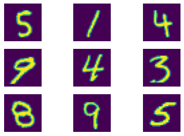

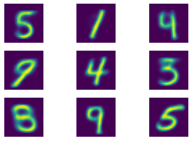

```python
'''
Wizualizacja wyników:
    1. Zwykła rekonstrukcja dla elementów zbioru walidacyjnego
    2. Zabawa z generacją wyników:
        - generacja z wektorów losowych o wyuczonym rozkładzie
        - poprzez interpolację dwóch wektorów obserwacja modyfikacji
'''
n=3
vae.eval()
batch_size = n**2 # żeby łatwo wyświetlić wyniki
# zmiana parametrów loadera - inny batch size
val_loader = DataLoader(val_set, batch_size=batch_size, shuffle=True)

with torch.no_grad():
    img, _ = next(iter(val_loader))
    img = img.view(img.size(0),-1)
    out, _, _ = vae(img.to(device))

InImg = img.view(img.shape[0],1,28,28).cpu().data.numpy()
GenImg = out.view(out.shape[0],1,28,28).cpu().data.numpy()

imgs = [InImg, GenImg]

for k in range(len(imgs)):
    fig, axs = plt.subplots(n,n)
    for i in range(n):
        for j in range(n):
            axs[i,j].imshow(imgs[k][i*n+j,0,:,:])
            axs[i,j].axis('off')
```

W przeciwieństwie do zwykłych AE, VAE oferują przestrzeń ukrytą wypełnioną w sposób ciągły 'prototypami' obiektów. Ponieważ docelowym rozkładem, którego uczy się VAE jest rozkład normalny unormowany, dlatego też generacja dowolnego wektora losowego, którego komponenty są losowane z takiego rozkładu powinna skutkować wytworzeniem obrazu z rozkładu 'prototypów'

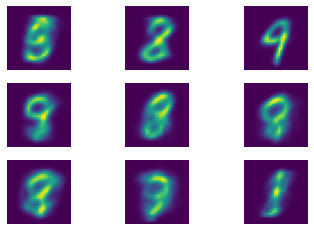

```python
'''
Generacja treści z wektorów losowych, interpolacja
'''
with torch.no_grad():
    noise = torch.randn(batch_size, latent_dim).to(device)
    gen_imgs = vae.generuj(noise)

gen_imgs = gen_imgs.view(gen_imgs.shape[0],1,28,28).cpu().data.numpy()

fig, axs = plt.subplots(n,n)
for i in range(n):
    for j in range(n):
        axs[i,j].imshow(gen_imgs[i*n+j,0,:,:])
        axs[i,j].axis('off')
```

Przykład

Ciągłość przestrzenna reprezentacji 'prototypów' obiektów może być zobrazowana poprzez śledzenie zmian, jakim podlegają generowane obrazy podczas stopniowego przekształcania jednego obrazu w drugi. Przekształcanie jest dokonywane w dziedzinie ukrytej jako wyznaczanie reprezentacji nowego obrazu w wyniku kombinacji liniowej obrazów 'brzegowych'.

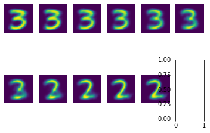

```python
batch_size=2
val_loader = DataLoader(val_set, batch_size=batch_size, shuffle=True)
img, _ = next(iter(val_loader))

res = []
for i in range(11):
    im1 = img[0,...].view(img[0,...].size(0),-1).to(device)
    im2 = img[1,...].view(img[1,...].size(0),-1).to(device)
    interp_img = vae.interpolacja(im1,im2,i/10)
    res.append(interp_img.view(-1,1,28,28).cpu().data.numpy())

fig, axs = plt.subplots(2,6)
for i in range(2):
    for j in range(6):
        axs[i,j].imshow(res[i*6+j][0,0,:,:])
        axs[i,j].axis('off')
        if i*6+j==10: break
```